# Assignment 5

Kimberly Juarez-Rico

10/24/2020

This report analyzes the accessibility of ballot drop off location sites for Sonoma County residents by race.

This report uses Mapbox, a data and mapping service, that allows open source map data for educational purposes by proving an access token. ACS 2018 CBG data is also used for this analysis

The objective in this report is to use Mapbox API, an R library, to map how accessible services are to a population group.

Downloaded necessary packages:

```r
library(lehdr)
library(mapboxapi)
library(tidyverse)
library(tigris)
library(sf)
library(leaflet)
library(censusapi)
library(janitor)
```

Used Census key and Mapbox access token:

```r
Sys.setenv(CENSUS_KEY="4f290b276a2a5526b13d917c76884e70b99ba725")
mb_access_token("pk.eyJ1Ijoia2p1YXJlenJpY28iLCJhIjoiY2tnamx6YXUyMDhlZTMxbDh3cjR2cnJzcSJ9.GfWXcAN9I6phMo8Kg08pFw")
readRenviron("~/.Renviron")
```

The next step in the analysis is to prepare locations for isochrones.

Load in Bay Area Community Data:

```r
BAC_database <- read_csv("SFBI Database.csv")
```

Get zip codes for Sonoma County only from Zip Code Tabulation Areas (ZCTA):

```r
usa_zips <-
  zctas(cb = T, progress_bar = F)

ca_counties <- counties("CA", cb = T, progress_bar = F)

soco <- "Sonoma"

soco_filter <-
  counties("CA", cb = T, progress_bar = F) %>%
  filter(NAME %in% soco)

soco_zips <-
  usa_zips %>%
  st_centroid() %>%
  .[soco_filter, ] %>%
  st_set_geometry(NULL) %>%
  left_join(usa_zips %>% select(GEOID10)) %>%
  st_as_sf()
```

Modify BAC Database so that it only shows ballot drop off locations and zip codes in Sonoma County:

```r
BAC_soco_polling <-
  BAC_database %>%
  filter(taxonomy %in%
      c(
        "Ballot Drop Off"
      )
  ) %>%
  mutate(
    zipcode = `Zip Code (from address) (from locations) 3` %>% as.character()
  ) %>%
  group_by(Name, `Zip Code (from address) (from locations) 3`, taxonomy,
           active) %>%
  right_join(
    soco_zips %>% select(GEOID10),
    by = c("zipcode" = "GEOID10")
  ) %>%
  st_as_sf() %>%
  st_transform(4326)%>%
  select(!geometry)

BAC_soco_polling
```

```
## Simple feature collection with 37 features and 42 fields
## Geometry type: MULTIPOLYGON
## Dimension:     XY
## Bounding box:  xmin: -123.5335 ymin: 38.10976 xmax: -122.3496 ymax: 38.93713
## Geodetic CRS:  WGS 84
## # A tibble: 37 x 43
## # Groups:   Name, Zip Code (from address) (from locations) 3, taxonomy, active
## #   [22]
##    Name  Organization    id Description `Translation Re~ Spanish_Descrip~
##    <chr> <chr>        <dbl> <chr>       <lgl>            <chr>
##  1 West~ <NA>          7989 Drop off y~ NA               ¡Deje su papele~
##  2 Bode~ <NA>          8030 Drop off y~ NA               ¡Deje su papele~
##  3 Sono~ <NA>          8045 Drop off y~ NA               ¡Deje su papele~
##  4 Sant~ <NA>          8046 Drop off y~ NA               ¡Deje su papele~
##  5 Peta~ <NA>          8047 Drop off y~ NA               ¡Deje su papele~
##  6 Clov~ <NA>          8048 Drop off y~ NA               ¡Deje su papele~
##  7 Cota~ <NA>          8049 Drop off y~ NA               ¡Deje su papele~
##  8 Dunc~ <NA>          8050 Drop off y~ NA               ¡Deje su papele~
##  9 Geys~ <NA>          8051 Drop off y~ NA               ¡Deje su papele~
## 10 Glen~ <NA>          8052 Drop off y~ NA               ¡Deje su papele~
## # ... with 27 more rows, and 37 more variables: locations <chr>, `address_1
## #   (from address) (from locations) 2` <chr>, `city (from address) (from
## #   locations) 3` <chr>, `Zip Code (from address) (from locations) 3` <chr>,
## #   `latitude (from locations) 2` <chr>, `longitude (from locations) 2` <chr>,
## #   url <chr>, email <chr>, active <chr>, application_process <chr>,
## #   service_options <chr>, payment_options <chr>, taxonomy <chr>, phones <chr>,
## #   schedule <chr>, `weekday (from schedule) 3` <chr>, `opens_at (from
## #   schedule) 3` <chr>, `closes_at (from schedule) 3` <chr>, `add_day (from
## #   schedule) 4` <chr>, `add_hours (from schedule) 4` <chr>, med_area <chr>,
## #   legal_area <lgl>, cash_area <lgl>, dv_area <lgl>, foodstamp_area <lgl>,
## #   freefood_area <chr>, details <chr>, service_area <chr>, `Last
## #   updated` <chr>, `Updated By` <chr>, owner <chr>, status <chr>, `Auto-Last
## #   updated` <chr>, `Auto-Last updated by` <chr>,
## #   `Questions/Confusions/Observations` <chr>, zipcode <chr>,
## #   geometry <MULTIPOLYGON [°]>
```

Remove empty columns:

```r
BAC_soco_polling_filter <-
  BAC_soco_polling%>%
  select(Name, zipcode, taxonomy, active,
  `address_1 (from address) (from locations) 2`, `latitude (from locations) 2`,
  `longitude (from locations) 2`)
```

Create a final data set that filters out empty rows:

```r
BAC_soco_polling_final <-
BAC_soco_polling_filter[1:21, ]

BAC_soco_polling_final
```

```
## Simple feature collection with 21 features and 7 fields
## Geometry type: MULTIPOLYGON
## Dimension:     XY
## Bounding box:  xmin: -123.2726 ymin: 38.10976 xmax: -122.3496 ymax: 38.93713
## Geodetic CRS:  WGS 84
## # A tibble: 21 x 8
## # Groups:   Name, taxonomy, active [21]
##    Name  zipcode taxonomy active `address_1 (fro~ `latitude (from~
##    <chr> <chr>   <chr>    <chr>  <chr>            <chr>
##  1 West~ 94952   Ballot ~ Open   1 Sixth Street   38.231605
##  2 Bode~ 94923   Ballot ~ Open   510 Highway 1    38.322954
##  3 Sono~ 95403   Ballot ~ Open   435 Fiscal Drive 38.4655257
##  4 Sant~ 95404   Ballot ~ Open   1351 Maple Aven~ 38.4338261
##  5 Peta~ 94952   Ballot ~ Open   1094 Petaluma B~ 38.227386
##  6 Clov~ 95425   Ballot ~ Open   205 West 1st St~ 38.80468
##  7 Cota~ 94931   Ballot ~ Open   8505 Park Avenue 38.322348
##  8 Dunc~ 95462   Ballot ~ Open   24900 Highway 1~ 38.467103
##  9 Geys~ 95441   Ballot ~ Open   20975 Geyservil~ 38.7062705
## 10 Glen~ 95442   Ballot ~ Open   13445 Arnold Dr~ 38.367713
## # ... with 11 more rows, and 2 more variables: `longitude (from locations)
## #   2` <chr>, geometry <MULTIPOLYGON [°]>
```

Creates a 10 minute walking distance isochrone for Sonoma County Ballot Drop Off Location:

```r
walk_10min <- mb_isochrone(
  BAC_soco_polling_final,
  profile = "walking",
  time = 10
)

soco_polling_walk_10min <-
  BAC_soco_polling_final %>%
  st_set_geometry(NULL) %>%
  cbind(walk_10min$geometry) %>%
  st_as_sf()
```

Creates a map using mapbox api isochrones for a 10 minute walking distance from a ballot drop off location in Sonoma County:

```r
leaflet() %>%
  addMapboxTiles(
    style_id = "streets-v11",
    username = "mapbox"
  ) %>%
  addPolygons(
    data = soco_polling_walk_10min,
    label = ~Name
  )
```

[interactive chart not shown]

Second part of the analysis is to use ACS data that divides populations by race from the years 2017 to estimate if there is a relationship between the race of people in Sonoma County and if they are able to access a ballot drop off location within a 10 minute walking time.

I was not able to find 2017 ACS data at the Census Block Group level so I chose to use 2018 5 year ACS data which includes 2017.

Sonoma County Census Block Groups without duplicates:

```r
soco_bg <-
  block_groups("CA","097", cb = T, progress_bar = F) %>%
  st_transform(26910) %>%
  mutate(original_area = st_area(.))
```

Load ACS 2018 5 year data that includes patterns for the years 2014-2018 and will include 2017 Census Block Group data:

```r
acs_vars_2018_5yr <-
  listCensusMetadata(
    name = "2018/acs/acs5",
    type = "variables"
  )
```

Census code B02001 = Race

Brings in Census Block Group data and filters groups by race:

```r
soco_bg_race <-
  getCensus(
    name = "acs/acs5",
    vintage = 2018,
    region = "block group:*",
    regionin = "state:06+county:097",
    vars = "group(B02001)"
  ) %>%
  mutate(cbg = paste0(state,county,tract,block_group)) %>%
  select(!c(GEO_ID,state,county,tract,block_group,NAME) & !ends_with(c("EA","MA","M"))) %>%
  pivot_longer(
    ends_with("E"),
    names_to = "variable",
    values_to = "estimate"
  ) %>%
  left_join(
    acs_vars_2018_5yr %>%
      select(name, label),
    by = c("variable" = "name")
  ) %>%
  select(-variable) %>%
  separate(
    label,
    into = c(NA,NA,"race"),
    sep = "!!"
  ) %>%
  filter(!is.na(race)) %>%
  mutate(
    race = case_when(
      race %in% c("White alone") ~ "White, Alone",
      race %in% c("Black or African American alone") ~ "Black or African American Alone",
      race %in% c("Asian alone") ~ "Asian Alone",
      race %in% c("American Indian and Alaska Native alone") ~ "American Indian and Alaska Native Alone",
      race %in% c("Native Hawaiian or Other Pacific Islander Alone") ~ "Native Hawaiian or Other Pacific Islander",
      race %in% c("Two or more races") ~"Two or More Race Groups",
      race %in% c("Some other race alone") ~"Some Other Race Alone",
      TRUE ~ race
    )
  )
```

Estimates the population totals for each racial group and creates a perscentage calculation of each group divided by the total population:

```r
soco_race_totals <-
  soco_bg_race %>%
  mutate(race = factor(race, levels = unique(soco_bg_race$race))) %>%
  group_by(race) %>%
  summarize(estimate = sum(estimate)) %>%
  mutate(
    perc = estimate/sum(estimate),
    group = "Full Population"
  )
```

Creates the intersects of Sonoma County Block Groups and areas within a 10 minute walking distance of a polling place in Sonoma County:

```r
soco_bg_isochrone_intersect <-
  soco_bg %>%
  st_intersection(
    soco_polling_walk_10min %>%
      st_union() %>%
      st_transform(26910)
  ) %>%
  mutate(
    leftover_area = st_area(.),
    perc_area = leftover_area / original_area
  )
```

Creates a new data set that takes the Census Block Group of each value in the racial catergory and matches the isochrones within that data set to the isochrones of 10 minutes of walking distance to a ballot drop off location in Sonoma County:

```r
soco_poll_race <-
  soco_bg_race %>%
  mutate(race = factor(race, levels = unique(soco_bg_race$race))) %>%
  left_join(
    soco_bg_isochrone_intersect %>%
      select(cbg = GEOID, perc_area) %>%
      st_set_geometry(NULL)
  ) %>%
  filter(!is.na(perc_area)) %>%
  mutate(
    estimate = estimate * perc_area
  ) %>%
  group_by(race) %>%
  summarize(estimate = sum(estimate)) %>%
  mutate(
    perc = estimate/sum(estimate),
    group = "Population within 10 min. walk of Ballot Drop Off"
  )
```

Renders 2 charts:

The first chart shows the full population that has access to ballot drop of locations in Sonoma County by race.

The second chart shows the access that the population that has access to ballet drop off locations that are within a 10 minute walking time isochrone in Sonoma County by race.

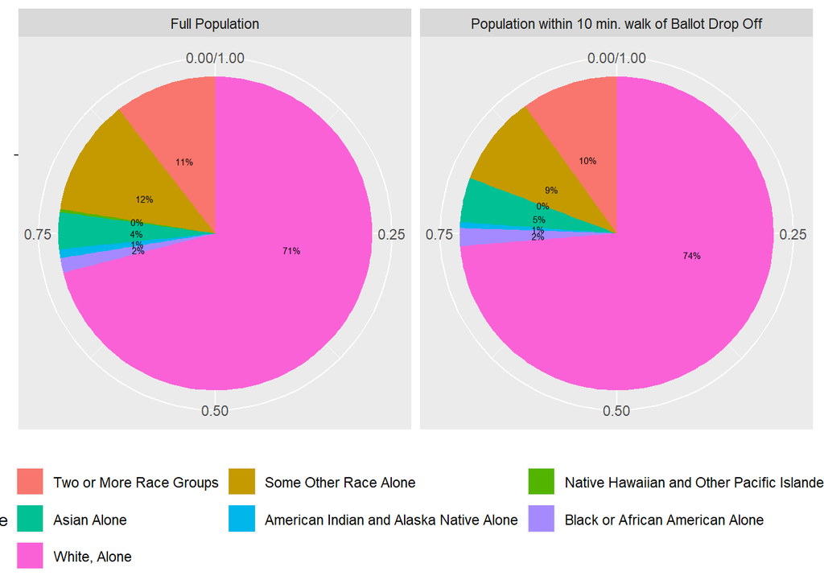

```r
rbind(soco_race_totals,soco_poll_race) %>%
  ggplot(
    aes(
      x = "",
      y = perc,
      fill = reorder(race,desc(race))
    )
  ) +
  geom_bar(
    stat = "identity",
    position = position_fill()
  ) +
  geom_text(
    aes(label = paste0(round(perc*100),"%")),
    position = position_fill(vjust = 0.4), size = 2,
  ) +
  coord_polar(theta = "y") +
  facet_wrap(~ group)  +
  theme(
    axis.title.x = element_blank(),
    axis.title.y = element_blank(),
    legend.position = 'bottom'
  ) +
  guides(
    fill = guide_legend(nrow=3, byrow=TRUE)
  ) +
  labs(
    fill = "Race"
  )
```

Sources:

BayAreaCommunity.org

unboxproject.org

https://dcl-covid-19.github.io/mega-map-dev/#/

https://www.mapbox.com/

https://www.census.gov/programs-surveys/geography/guidance/geo-areas/zctas.html